# Final Exam

For # 3 First visit https://github.com/rfordatascience/tidytuesday/tree/master/data/2019/2019-09-10 to learn more about the data. You will only need to read in the following file: tx_injuries.csv * Use select to obtain the columns: name_of_operation, ride_name, gender, age and body_part. Omit the other columns * Obtain the rows that include the name of operations of Schlitterbahn and Six Flags. Omit the others. Note: there are 8 different parks include the name of operations of Schlitterbahn and Six Flags: Schlitterbahn Galveston Schlitterbahn - New Braunfels Schlitterbahn-New Branufels Schlitterbahn Beach Waterpark - South Padre Island Schlitterbahn Galveston Island Six Flags Fiesta Texas Six Flags - Hurricane Harbor Six Flags Over Texas

```r
library(tidyverse)
dataURL = "https://raw.githubusercontent.com/rfordatascience/tidytuesday/master/data/2019/2019-09-10/tx_injuries.csv"
injuries = read_csv(dataURL)
head(injuries)
```

| injury_report_rec | name_of_operation | city | st | injury_date | ride_name | serial_no | gender | age | body_part | alleged_injury | cause_of_injury | other |
| --- | --- | --- | --- | --- | --- | --- | --- | --- | --- | --- | --- | --- |
| 2032 | Skygroup Investments LLC DBA iFly Austin | Austin | TX | 2/12/2013 | I Fly | SV024 | F | 37 | Mouth | Student hit mouth on wall | Student attempted unfamiliar manuever | NA |
| 1897 | Willie G's Post Oak Inc. - Pleasure Pier | Galveston | TX | 3/2/2013 | Gulf Glider | GS-11-10-WG-14 | F | 43 | Knee | Alleged arthroscopy to knee | Hit her knee on a chair on the ride | Prior history of problems with this knee. First told of injuries in June 2014 upon receipt of a lawsuit. Discovery and investigation is ongoing. |
| 837 | Great Wolf Lodge | Grapevine | TX | 3/3/2013 | Howlin Tornado | 0643-C1-T1-TN60 | F | n/a | Right Shoulder | Pain in shoulder | Injured person fell out of raft and hit her shoulder on the slide | NA |
| 99 | Six Flags Fiesta Texas | San Antonio | TX | 3/3/2013 | Scooby Doo Ghost Blasters | n/a | F | 51 | Lower Leg | Contusion | Guest backed into advancing car | n/a |
| 55 | Ray Cammack Shows, Inc. (RCS) | Laveen | AZ | 3/11/2013 | Alien Abduction | 862162 | F | 17 | Head | Laceration | unknown guest did not report to operator or attendant | Upon investigation found no areas of concern at ride |
| 780 | ZDT's Amusement Center LTD | Seguin | TX | 3/12/2013 | Go Karts | n/a | F | 40 | Bottom of foot | cut requiring stitches on bottom of foot | had taken her shoes off and was driving barefoot - hit railing | NA |

```r
injuries$age = as.numeric(injuries$age)
```

- Omit any rows with missing data in the columns age or gender.

```r
injuries = injuries %>%
  drop_na(age, gender) %>%
  subset(!(age %in% c("n/a", "N/A"))) %>%
  subset(!(gender %in% c("n/a", "N/A")))
```

- Using a bargraph (or histogram), show the total number injured for each of 8 amusement parks in our data. Write a two sentence explanation of the graph. ###Question - Do we need to consider other names for the same place?

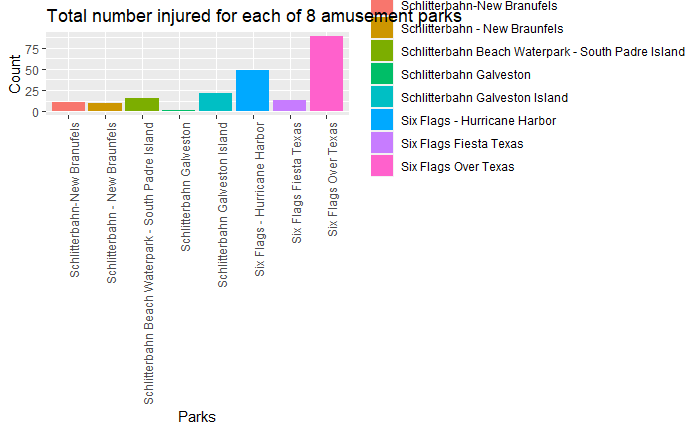

```r
injuries %>%
  group_by(name_of_operation) %>%
  filter(name_of_operation %in% c("Schlitterbahn Galveston",
                                  "Schlitterbahn - New Braunfels",
                                  "Schlitterbahn-New Branufels",
                                  "Schlitterbahn Beach Waterpark - South Padre Island",
                                  "Schlitterbahn Galveston Island",
                                  "Six Flags Fiesta Texas",
                                  "Six Flags - Hurricane Harbor",
                                  "Six Flags Over Texas")) %>%
  ggplot(aes(x = name_of_operation, fill = name_of_operation)) +
  geom_bar() +
  theme(axis.text.x = element_text(angle = 90, hjust=1)) +
  labs(title = "Total number injured for each of 8 amusement parks", x = "Parks", y = "Count")
```

- Using a bargraph (or histogram), show the average age for each of the 8 amusement parks. Write a two sentence explanation of the graph.

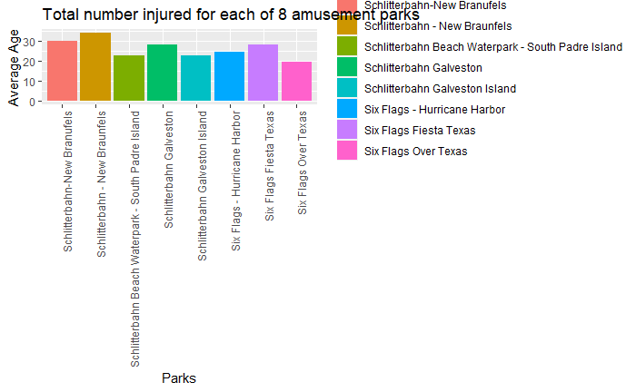

```r
injuries %>%
  group_by(name_of_operation) %>%
  summarise(avg = mean(age)) %>%
  filter(name_of_operation %in% c("Schlitterbahn Galveston",
                                  "Schlitterbahn - New Braunfels",
                                  "Schlitterbahn-New Branufels",
                                  "Schlitterbahn Beach Waterpark - South Padre Island",
                                  "Schlitterbahn Galveston Island",
                                  "Six Flags Fiesta Texas",
                                  "Six Flags - Hurricane Harbor",
                                  "Six Flags Over Texas")) %>%
  ggplot(aes(x = name_of_operation, y = avg, fill = name_of_operation)) +
  geom_bar(stat = "identity") +
  theme(axis.text.x = element_text(angle = 90, hjust=1)) +
  labs(title = "Total number injured for each of 8 amusement parks", x = "Parks", y = "Average Age")
```

- Using a bargraph (or histogram), show the average age for each gender for each of the 8 amusement parks. Write a two sentence explanation of the graph.

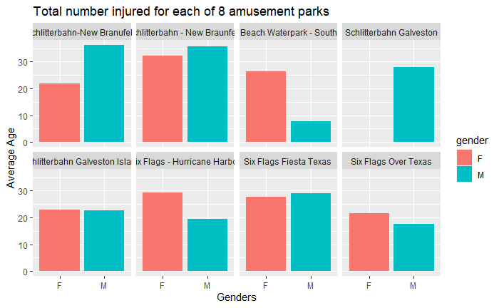

```r
injuries %>%
  group_by(name_of_operation, gender) %>%
  summarise(avg = mean(age)) %>%
  filter(name_of_operation %in% c("Schlitterbahn Galveston",
                                  "Schlitterbahn - New Braunfels",
                                  "Schlitterbahn-New Branufels",
                                  "Schlitterbahn Beach Waterpark - South Padre Island",
                                  "Schlitterbahn Galveston Island",
                                  "Six Flags Fiesta Texas",
                                  "Six Flags - Hurricane Harbor",
                                  "Six Flags Over Texas")) %>%
  ggplot(aes(x = gender, y = avg, fill = gender)) +
  geom_bar(stat = "identity") +
  labs(title = "Total number injured for each of 8 amusement parks", x = "Genders", y = "Average Age") +
  facet_wrap(~name_of_operation, ncol = 4)
```

- Using a bargraph (or histogram), show the total number of injured for each gender. Write a two sentence explanation of the graph.

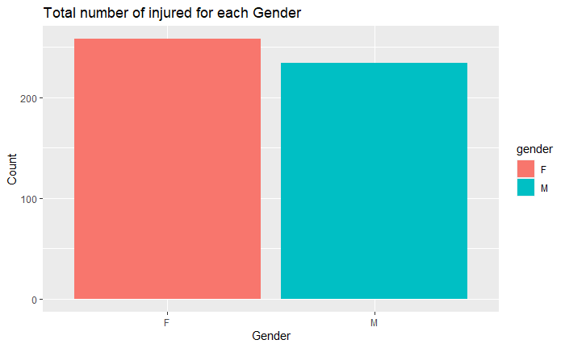

```r
injuries$gender[injuries$gender == "m"] = "M"

injuries %>%
  group_by(gender) %>%
  ggplot(aes(x = gender, fill = gender)) +
  geom_bar() +
  labs(title = "Total number of injured for each Gender", x = "Gender", y = "Count")
```

- Split the data into two data frames. 1 for ‘Schlitterbahn’ parks and ‘Six Flags’ parks.

```r
Schlitterbahn = injuries %>%
  group_by(name_of_operation) %>%
  filter(name_of_operation %in% c("Schlitterbahn Galveston",
                                  "Schlitterbahn - New Braunfels",
                                  "Schlitterbahn-New Branufels",
                                  "Schlitterbahn Beach Waterpark - South Padre Island",
                                  "Schlitterbahn Galveston Island"))

Six_Flags = injuries %>%
  group_by(name_of_operation) %>%
  filter(name_of_operation %in% c("Six Flags Fiesta Texas",
                                  "Six Flags - Hurricane Harbor",
                                  "Six Flags Over Texas"))
```

```r
injuries = injuries %>%
  drop_na(age, gender) %>%
  subset(!(gender %in% c("n/a", "N/A")))
```

- Find the number of males and females injured at each park (i.e., name_of_operation)

```r
injuries %>%
  group_by(name_of_operation, gender) %>%
  count(name_of_operation)
```

| name_of_operation | gender | n |
| --- | --- | --- |
| Apex Parks Group DBA Boomers-Houston DBA Mountasia of Willowbrook | M | 1 |
| APEX PARKS GROUP DBA BOOMERS - HOUSTON DBA MOUNTASIA OF WILLOWBROOK | F | 1 |
| ARW Kiddie Park | F | 1 |
| Austin Park LLC DBA Nland Surf Park | F | 1 |
| Austin Park LLC DBA Nland Surf Park | M | 3 |
| Barbara Loretta Tovar - Sun City Amusements | F | 1 |
| Barbara Loretta Tovar - Sun City Amusements | M | 1 |
| Celebration Station Mesquite | F | 3 |
| Celebration Station Mesquite | M | 3 |
| Dallas Speed Zone - Apex Parks Group LLC | F | 7 |

[output cut: 86 more lines]

- Run a t-test comparing the number males and females injured.

```r
t.test(name_of_operation ~ gender, data = injuries)
```

[output not shown]

For # 10 First visit: https://github.com/rfordatascience/tidytuesday/tree/master/data/2019/2019-01-29 You will only need to read in the following file: milkcow_facts.csv

```r
dataURLMilkcow = "https://raw.githubusercontent.com/rfordatascience/tidytuesday/master/data/2019/2019-01-29/milkcow_facts.csv"
milkcow = read_csv(dataURLMilkcow)
head(milkcow)
```

| year | avg_milk_cow_number | milk_per_cow | milk_production_lbs | avg_price_milk | dairy_ration | milk_feed_price_ratio | milk_cow_cost_per_animal | milk_volume_to_buy_cow_in_lbs | alfalfa_hay_price | slaughter_cow_price |
| --- | --- | --- | --- | --- | --- | --- | --- | --- | --- | --- |
| 1980 | 10799000 | 11891 | 1.28406e+11 | 0.130 | 0.04837357 | 2.717149 | 1190 | 9153.846 | 72.00000 | 0.4573 |
| 1981 | 10898000 | 12183 | 1.32770e+11 | 0.138 | 0.05035243 | 2.759031 | 1200 | 8695.652 | 70.90000 | 0.4193 |
| 1982 | 11011000 | 12306 | 1.35505e+11 | 0.136 | 0.04422102 | 3.088127 | 1110 | 8161.765 | 72.73333 | 0.3996 |
| 1983 | 11059000 | 12622 | 1.39588e+11 | 0.136 | 0.05235034 | 2.609620 | 1030 | 7573.529 | 78.70000 | 0.3935 |
| 1984 | 10793000 | 12541 | 1.35351e+11 | 0.135 | 0.05338787 | 2.540000 | 895 | 6629.630 | 79.48333 | 0.3981 |
| 1985 | 10981000 | 13024 | 1.43012e+11 | 0.127 | 0.04500457 | 2.840000 | 860 | 6771.654 | 73.67500 | 0.3831 |

- Use select to obtain the columns: year, avg_milk_cow_number, milk_per_cow, avg_price_milk, milk_cow_cost_per_animal, alfalfa_hay_price and slaughter_cow_price. Omit all other columns

```r
milkcow = milkcow %>%
  select(year, avg_milk_cow_number, milk_per_cow, avg_price_milk, milk_cow_cost_per_animal, alfalfa_hay_price,slaughter_cow_price)
head(milkcow)
```

| year | avg_milk_cow_number | milk_per_cow | avg_price_milk | milk_cow_cost_per_animal | alfalfa_hay_price | slaughter_cow_price |
| --- | --- | --- | --- | --- | --- | --- |
| 1980 | 10799000 | 11891 | 0.130 | 1190 | 72.00000 | 0.4573 |
| 1981 | 10898000 | 12183 | 0.138 | 1200 | 70.90000 | 0.4193 |
| 1982 | 11011000 | 12306 | 0.136 | 1110 | 72.73333 | 0.3996 |
| 1983 | 11059000 | 12622 | 0.136 | 1030 | 78.70000 | 0.3935 |
| 1984 | 10793000 | 12541 | 0.135 | 895 | 79.48333 | 0.3981 |
| 1985 | 10981000 | 13024 | 0.127 | 860 | 73.67500 | 0.3831 |

- Omit any NAs from year, avg_milk_cow_number, milk_per_cow, avg_price_milk, milk_cow_cost_per_animal, alfalfa_hay_price or slaughter_cow_price

```r
milkcow = milkcow %>%
  drop_na(year, avg_milk_cow_number, milk_per_cow, avg_price_milk, milk_cow_cost_per_animal, alfalfa_hay_price,slaughter_cow_price)
head(milkcow)
```

| year | avg_milk_cow_number | milk_per_cow | avg_price_milk | milk_cow_cost_per_animal | alfalfa_hay_price | slaughter_cow_price |
| --- | --- | --- | --- | --- | --- | --- |
| 1980 | 10799000 | 11891 | 0.130 | 1190 | 72.00000 | 0.4573 |
| 1981 | 10898000 | 12183 | 0.138 | 1200 | 70.90000 | 0.4193 |
| 1982 | 11011000 | 12306 | 0.136 | 1110 | 72.73333 | 0.3996 |
| 1983 | 11059000 | 12622 | 0.136 | 1030 | 78.70000 | 0.3935 |
| 1984 | 10793000 | 12541 | 0.135 | 895 | 79.48333 | 0.3981 |
| 1985 | 10981000 | 13024 | 0.127 | 860 | 73.67500 | 0.3831 |

- Using a line graph, show avg_milk_cow_number and year. Write a two sentence explanation of the graph.

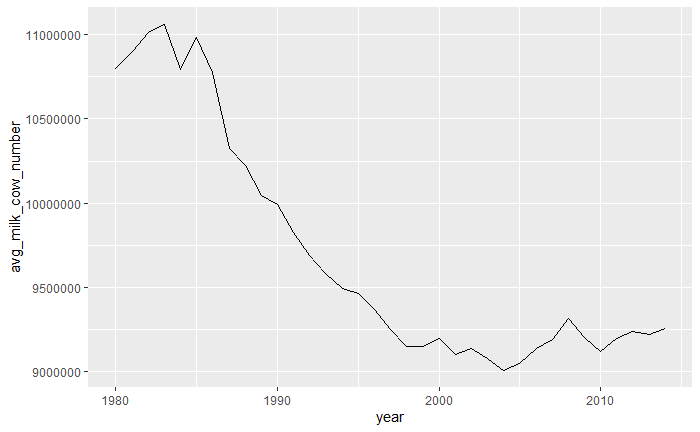

```r
milkcow %>%
  ggplot(aes(x = year, y = avg_milk_cow_number)) +
  geom_line()
```

- Using a line graph, show milk_per_cow and year. Write a two sentence explanation of the graph.

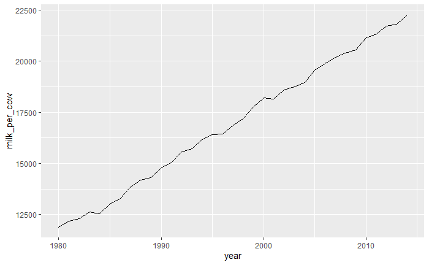

```r
milkcow %>%
  ggplot(aes(x = year, y = milk_per_cow)) +
  geom_line()
```

- Using a line graph, show avg_price_milk and year. Write a two sentence explanation of the graph.

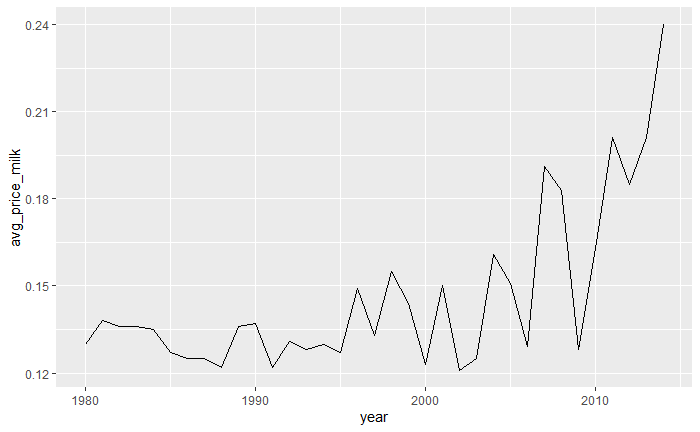

```r
milkcow %>%
  ggplot(aes(x = year, y = avg_price_milk)) +
  geom_line()
```

- find the scatter plot of avg_milk_cow_number and milk_cow_cost_per_animal. Does the plot reveal any relationship between the variables? Write a two sentence explanation of the graph.

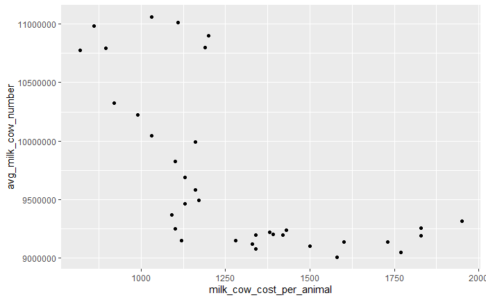

```r
milkcow %>%
  ggplot(aes(x = milk_cow_cost_per_animal, y = avg_milk_cow_number )) +
  geom_point()
```

- find the scatter plot of avg_milk_cow_number and slaughter_cow_price. Does the plot reveal any relationship between the variables? Write a two sentence explanation of the graph.

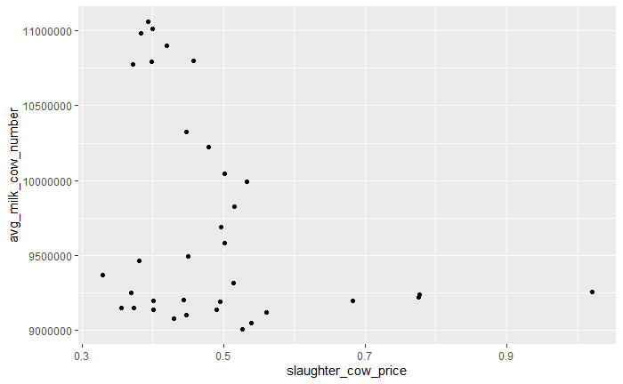

```r
milkcow %>%
  ggplot(aes(x = slaughter_cow_price, y = avg_milk_cow_number )) +
  geom_point()
```

- find the scatter plot of avg_milk_cow_number and avg_price_milk. Does the plot reveal any relationship between the variables? Write a two sentence explanation of the graph.

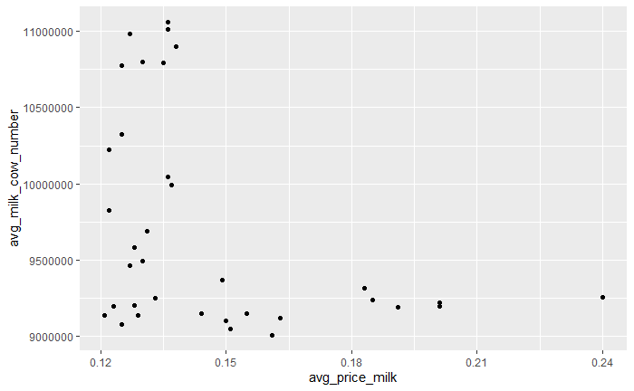

```r
milkcow %>%
  ggplot(aes(x = avg_price_milk, y = avg_milk_cow_number )) +
  geom_point()
```

- Run a regression on avg_milk_cow_number with slaughter_cow_price as the predictor.

```r
LinReg = lm(slaughter_cow_price ~ avg_milk_cow_number, data = milkcow)
summary(LinReg)
```

```
Call:
lm(formula = slaughter_cow_price ~ avg_milk_cow_number, data = milkcow)

Residuals:
     Min       1Q   Median       3Q      Max
-0.17716 -0.07471 -0.00808  0.02925  0.50626

Coefficients:
                      Estimate Std. Error t value Pr(>|t|)
(Intercept)          1.076e+00  3.231e-01   3.330  0.00215 **
avg_milk_cow_number -6.070e-08  3.324e-08  -1.826  0.07695 .
---
Signif. codes:  0 ‘***’ 0.001 ‘**’ 0.01 ‘*’ 0.05 ‘.’ 0.1 ‘ ’ 1

Residual standard error: 0.1351 on 33 degrees of freedom
Multiple R-squared:  0.09175,   Adjusted R-squared:  0.06422
F-statistic: 3.333 on 1 and 33 DF,  p-value: 0.07695
```

```r
LinReg = lm(milk_cow_cost_per_animal ~ avg_milk_cow_number, data = milkcow)
summary(LinReg)
```

```
Call:
lm(formula = milk_cow_cost_per_animal ~ avg_milk_cow_number,
    data = milkcow)

Residuals:
    Min      1Q  Median      3Q     Max
-316.07 -155.21  -61.84  145.31  559.73

Coefficients:
                      Estimate Std. Error t value Pr(>|t|)
(Intercept)          4.007e+03  5.331e+02   7.517 1.21e-08 ***
avg_milk_cow_number -2.810e-04  5.485e-05  -5.123 1.28e-05 ***
---
Signif. codes:  0 ‘***’ 0.001 ‘**’ 0.01 ‘*’ 0.05 ‘.’ 0.1 ‘ ’ 1

Residual standard error: 222.8 on 33 degrees of freedom
Multiple R-squared:  0.443, Adjusted R-squared:  0.4261
F-statistic: 26.25 on 1 and 33 DF,  p-value: 1.282e-05
```

```r
LinReg = lm(avg_price_milk ~ avg_milk_cow_number , data = milkcow)
summary(LinReg)
```

```
Call:
lm(formula = avg_price_milk ~ avg_milk_cow_number, data = milkcow)

Residuals:
      Min        1Q    Median        3Q       Max
-0.033863 -0.019683 -0.004619  0.009029  0.086967

Coefficients:
                      Estimate Std. Error t value Pr(>|t|)
(Intercept)          2.966e-01  6.349e-02   4.671 4.84e-05 ***
avg_milk_cow_number -1.551e-08  6.532e-09  -2.374   0.0236 *
---
Signif. codes:  0 ‘***’ 0.001 ‘**’ 0.01 ‘*’ 0.05 ‘.’ 0.1 ‘ ’ 1

Residual standard error: 0.02654 on 33 degrees of freedom
Multiple R-squared:  0.1459,    Adjusted R-squared:   0.12
F-statistic: 5.637 on 1 and 33 DF,  p-value: 0.02356
```

For #4 First visit: https://github.com/rfordatascience/tidytuesday/tree/master/data/2019/2019-07-30 You will only need to read in the following file: video_games.csv

```r
dataURLVideogames = "https://raw.githubusercontent.com/rfordatascience/tidytuesday/master/data/2019/2019-07-30/video_games.csv"
videoGames = read_csv(dataURLVideogames)
head(videoGames)
```

| number | game | release_date | price | owners | developer | publisher | average_playtime | median_playtime | metascore |
| --- | --- | --- | --- | --- | --- | --- | --- | --- | --- |
| 1 | Half-Life 2 | Nov 16, 2004 | 9.99 | 10,000,000 .. 20,000,000 | Valve | Valve | 110 | 66 | 96 |
| 3 | Counter-Strike: Source | Nov 1, 2004 | 9.99 | 10,000,000 .. 20,000,000 | Valve | Valve | 236 | 128 | 88 |
| 21 | Counter-Strike: Condition Zero | Mar 1, 2004 | 9.99 | 10,000,000 .. 20,000,000 | Valve | Valve | 10 | 3 | 65 |
| 47 | Half-Life 2: Deathmatch | Nov 1, 2004 | 4.99 | 5,000,000 .. 10,000,000 | Valve | Valve | 0 | 0 | NA |
| 36 | Half-Life: Source | Jun 1, 2004 | 9.99 | 2,000,000 .. 5,000,000 | Valve | Valve | 0 | 0 | NA |
| 52 | CS2D | Dec 24, 2004 | NA | 1,000,000 .. 2,000,000 | Unreal Software | Unreal Software | 16 | 10 | NA |

- Use select to obtain the columns: game, release_date, price, average_playtime and metascore. Omit the other columns

```r
videoGames = videoGames %>%
  select(game, release_date, price, average_playtime, metascore)
head(videoGames)
```

| game | release_date | price | average_playtime | metascore |
| --- | --- | --- | --- | --- |
| Half-Life 2 | Nov 16, 2004 | 9.99 | 110 | 96 |
| Counter-Strike: Source | Nov 1, 2004 | 9.99 | 236 | 88 |
| Counter-Strike: Condition Zero | Mar 1, 2004 | 9.99 | 10 | 65 |
| Half-Life 2: Deathmatch | Nov 1, 2004 | 4.99 | 0 | NA |
| Half-Life: Source | Jun 1, 2004 | 9.99 | 0 | NA |
| CS2D | Dec 24, 2004 | NA | 16 | NA |

- Omit any rows with missing data in game, release_date, price, average_playtime or metascore.

```r
videoGames = videoGames %>%
  drop_na(game, release_date, price, average_playtime, metascore)
head(videoGames)
```

| game | release_date | price | average_playtime | metascore |
| --- | --- | --- | --- | --- |
| Half-Life 2 | Nov 16, 2004 | 9.99 | 110 | 96 |
| Counter-Strike: Source | Nov 1, 2004 | 9.99 | 236 | 88 |
| Counter-Strike: Condition Zero | Mar 1, 2004 | 9.99 | 10 | 65 |
| Unreal Tournament 2004: Editor's Choice Edition | Mar 16, 2004 | 14.99 | 0 | 93 |
| DOOM 3 | Aug 3, 2004 | 4.99 | 0 | 87 |
| Beyond Divinity | Apr 27, 2004 | 5.99 | 0 | 73 |

- Extract the year from release_date

```r
videoGames$year = as.numeric(str_sub(videoGames$release_date,-4))
videoGames
```

| game | release_date | price | average_playtime | metascore | year |
| --- | --- | --- | --- | --- | --- |
| Half-Life 2 | Nov 16, 2004 | 9.99 | 110 | 96 | 2004 |
| Counter-Strike: Source | Nov 1, 2004 | 9.99 | 236 | 88 | 2004 |
| Counter-Strike: Condition Zero | Mar 1, 2004 | 9.99 | 10 | 65 | 2004 |
| Unreal Tournament 2004: Editor's Choice Edition | Mar 16, 2004 | 14.99 | 0 | 93 | 2004 |
| DOOM 3 | Aug 3, 2004 | 4.99 | 0 | 87 | 2004 |
| Beyond Divinity | Apr 27, 2004 | 5.99 | 0 | 73 | 2004 |
| Gish | May 4, 2004 | 9.99 | 0 | 80 | 2004 |
| Neighbours from Hell Compilation | Feb 20, 2004 | 9.99 | 0 | 69 | 2004 |
| Silent Storm Gold Edition | Sep 9, 2004 | 9.99 | 0 | 83 | 2004 |
| Soldiers: Heroes of World War II | Jun 29, 2004 | 4.99 | 0 | 77 | 2004 |

[output cut: 990 more lines]

```r
videoGames = videoGames %>%
  filter(year != 2004)
head(videoGames)
```

| game | release_date | price | average_playtime | metascore | year |
| --- | --- | --- | --- | --- | --- |
| Grand Theft Auto: San Andreas | Jun 6, 2005 | 14.99 | 373 | 93 | 2005 |
| STAR WARS Knights of the Old Republic II - The Sith Lords | Feb 8, 2005 | 9.99 | 37 | 85 | 2005 |
| Sid Meier's Civilization IV | Oct 25, 2005 | 19.99 | 0 | 94 | 2005 |
| Serious Sam 2 | Oct 11, 2005 | 9.99 | 0 | 74 | 2005 |
| Sid Meier's Pirates! | Jul 11, 2005 | 9.99 | 0 | 88 | 2005 |
| Darwinia | Jul 14, 2005 | 9.99 | 0 | 84 | 2005 |

- Using a bargraph (or histogram), show the average metascore for games by year. Write a two sentence explanation of the graph.

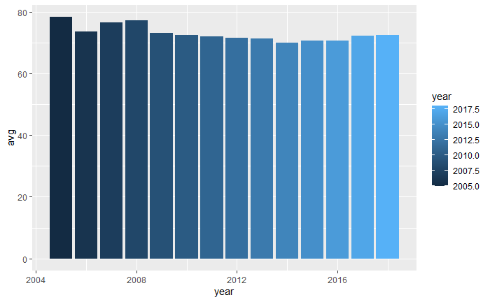

```r
videoGames %>%
  group_by(year) %>%
  summarise(avg = mean(metascore)) %>%
  ggplot(aes(x = year, y = avg, fill = year)) +
  geom_bar(stat = "identity")
```

- Using a bargraph (or histogram), show the average price for games by year. Write a two sentence explanation of the graph.

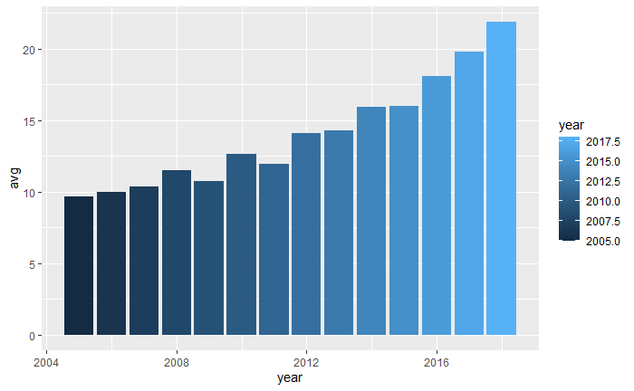

```r
videoGames %>%
  group_by(year) %>%
  summarise(avg = mean(price)) %>%
  ggplot(aes(x = year, y = avg, fill = year)) +
  geom_bar(stat = "identity")
```

- Find the scatter plot of price and metascore. Does the plot reveal any relationship between the variables? Write a two sentence explanation of the graph.

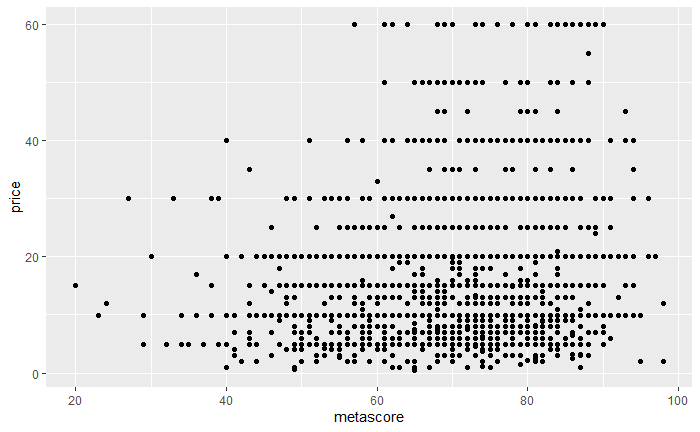

```r
videoGames %>%
  ggplot(aes(x = metascore, y = price)) +
  geom_point()
```

- Find the scatter plot of average_playtime and metascore. Does the plot reveal any relationship between the variables? Write a two sentence explanation of the graph.

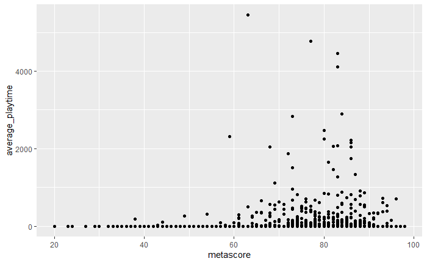

```r
videoGames %>%
  ggplot(aes(x = metascore, y = average_playtime)) +
  geom_point()
```

- Find the scatter plot of average_playtime and price. Does the plot reveal any relationship between the variables? Write a two sentence explanation of the graph.

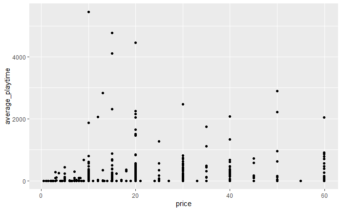

```r
videoGames %>%
  ggplot(aes(x = price, y = average_playtime)) +
  geom_point()
```

- Run a regression on price with metascore as the predictor.

```r
LinReg = lm(metascore ~ price, data = videoGames)
summary(LinReg)
```

```
Call:
lm(formula = metascore ~ price, data = videoGames)

Residuals:
    Min      1Q  Median      3Q     Max
-51.730  -5.846   1.270   7.385  28.569

Coefficients:
            Estimate Std. Error t value Pr(>|t|)
(Intercept) 69.07956    0.38014 181.722   <2e-16 ***
price        0.17685    0.01982   8.924   <2e-16 ***
---
Signif. codes:  0 ‘***’ 0.001 ‘**’ 0.01 ‘*’ 0.05 ‘.’ 0.1 ‘ ’ 1

Residual standard error: 10.8 on 2654 degrees of freedom
Multiple R-squared:  0.02913,   Adjusted R-squared:  0.02877
F-statistic: 79.64 on 1 and 2654 DF,  p-value: < 2.2e-16
```

```r
LinReg = lm(metascore ~ average_playtime, data = videoGames)
summary(LinReg)
```

```
Call:
lm(formula = metascore ~ average_playtime, data = videoGames)

Residuals:
    Min      1Q  Median      3Q     Max
-51.724  -5.724   1.276   8.197  26.276

Coefficients:
                  Estimate Std. Error t value Pr(>|t|)
(Intercept)      7.172e+01  2.146e-01 334.297  < 2e-16 ***
average_playtime 4.189e-03  7.949e-04   5.269 1.48e-07 ***
---
Signif. codes:  0 ‘***’ 0.001 ‘**’ 0.01 ‘*’ 0.05 ‘.’ 0.1 ‘ ’ 1

Residual standard error: 10.91 on 2654 degrees of freedom
Multiple R-squared:  0.01035,   Adjusted R-squared:  0.00998
F-statistic: 27.76 on 1 and 2654 DF,  p-value: 1.48e-07
```

```r
LinReg = lm(price ~ average_playtime, data = videoGames)
summary(LinReg)
```

```
Call:
lm(formula = price ~ average_playtime, data = videoGames)

Residuals:
    Min      1Q  Median      3Q     Max
-37.101  -5.758  -0.787   4.242  44.242

Coefficients:
                  Estimate Std. Error t value Pr(>|t|)
(Intercept)      1.575e+01  2.060e-01  76.459  < 2e-16 ***
average_playtime 5.751e-03  7.631e-04   7.536 6.61e-14 ***
---
Signif. codes:  0 ‘***’ 0.001 ‘**’ 0.01 ‘*’ 0.05 ‘.’ 0.1 ‘ ’ 1

Residual standard error: 10.47 on 2654 degrees of freedom
Multiple R-squared:  0.02095,   Adjusted R-squared:  0.02058
F-statistic: 56.79 on 1 and 2654 DF,  p-value: 6.606e-14
```